# Maine Public Employee Retirement System (MainePERS): Modeling approach and simulation results

# 1 **Overview of key risk-sharing features**

# 2 **Summary of modeling approach**

## 2.1 Policy scenarios

To examine the impact of the MainePERS risk-sharing features on plan costs, funded status, and member benefit, we run the simulation under the following three policy scenarios.

1. **Shared-ADC and variable COLA** (MainePERS policy)
   - EEC = 48% * ADC, capped at 9% of payroll
   - ERC = 52% * ADC, capped at 12.5% of payroll
   - COLA: 0~2.5% (cola assumption valuation: 1.91%)
2. **Shared ADC and fixed COLA**
   - The shared-ADC policy is the same as 1.
   - COLA rate is fixed at 1.91%.
3. **EEC as a fixed percentage of normal cost**
   - Only normal cost is shared. EEC = 48% of normal cost (about 6~7% of payroll). Amortization costs are not shared with employees.
   - COLA rate is fixed at 1.91%.

**Note**: In 1 and 2, EEC rate can fall to as low as 0%. To make 3 comparable to 1 and 2, EEC are allowed to fall below 48% of NC if the total ADC rate is lower than 48% of NC due to negative amortization cost; EEC rate is still floored at 0%.

## 2.2 Investment return scenarios

1. Stochastic: 6.75% expected mean return, 12% standard deviation. This is just for purposes of initial analysis. Will be replaced by scenarios and capital market assumptions provided by Pew.

## 2.3 Model assumptions and Simplifications

- Benefit rules for Tier 1 Regular members are applied to all members. We will model three tiers in later versions: Tier 1 Regular (pre-2014 members), Tier 2 Regular (post-2014 members), and Special.
- Benefit rules for Tier 1 Regular members:
  - Normal retirement age: 60
  - Benefit factor: 2% per year of service
- Key valuation methods and assumptions:
  - Discount rate: 6.75%
  - Cost method: EAN
  - Asset smoothing: 3 years
  - Amortization of UAAL: 20-year level-percent closed amortization

## 2.4 Questions about valuation with variable COLA

We need to better understand how the adjustable COLA is reflected in actuarial valuation calculations of liability in MainePERS. We are not sure what assumption they use about future COLAs when calculating the COLA reduction needed to bring the contribution rates under the caps. There are at least two possibilities:

- Assume that the reduced COLA will be applied only in the next year, and then use the regular COLA assumptions (1.91%) for following years.
- Assume that the reduced COLA will be applied for all following years (this is like what SDRS does).

Also, we assume that the COLA reduction and suspension are only applied in the valuation of retiree liabilities, but not the active member liabilities.

# 3 **Simulation results**

## 3.1 Summary of investment return scenarios

Please note that investment return percentile points won’t correspond exactly with percentile points for employer contributions or other concepts. For example, the 10th percentile for the long-run investment return won’t occur at the same simulation as the 10th percentile for the PV of employer contributions.

Distribution of 30-year compound annual returns

2021-2050; percentiles of 1,000 runs

| 90th | 75th | 50th | 25th | 10th |
| --- | --- | --- | --- | --- |
| 9.5% | 8.3% | 6.8% | 5.4% | 3.9% |

## 3.2 Analysis of contributions

### 3.2.2 Distribution of long-term costs (Cost components add up)

Making the cost components add up to the PV of total contribution with terminal UAAL:

(Click tabs below to show tables)

#### PV of total contribution with terminal UAAL

Distribution of 30-year present value of total contribution plus terminal UAAL

| Policy | 90th | 75th | 50th | 25th | 10th |
| --- | --- | --- | --- | --- | --- |
| Shared ADC; caps; Variable COLA (MEPERS) | 160.0 | 136.4 | 100.0 | 43.0 | −22.2 |
| Shared ADC; caps; Fixed COLA | 175.6 | 143.8 | 97.8 | 37.5 | −32.7 |
| Shared NC; no caps; Fixed COLA | 176.3 | 139.9 | 95.2 | 35.5 | −32.7 |

#### PV of employer contribution

Distribution of 30-year present value of ERC

| Policy | 90th | 75th | 50th | 25th | 10th |
| --- | --- | --- | --- | --- | --- |
| Shared ADC; caps; Variable COLA (MEPERS) | 79.6 | 63.3 | 57.4 | 26.2 | 51.6 |
| Shared ADC; caps; Fixed COLA | 75.8 | 79.0 | 69.1 | 41.4 | 31.6 |
| Shared NC; no caps; Fixed COLA | 150.8 | 139.4 | 86.8 | 49.5 | 34.8 |

#### PV of employee contribution

Distribution of 30-year present value of EEC

| Policy | 90th | 75th | 50th | 25th | 10th |
| --- | --- | --- | --- | --- | --- |
| Shared ADC; caps; Variable COLA (MEPERS) | 57.3 | 45.6 | 41.3 | 18.9 | 37.1 |
| Shared ADC; caps; Fixed COLA | 54.6 | 56.9 | 49.8 | 29.8 | 22.7 |
| Shared NC; no caps; Fixed COLA | 31.6 | 30.1 | 29.8 | 25.3 | 19.5 |

#### PV of terminal UAAL

Distribution of present value of terminal UAAL (year 30)

| Policy | 90th | 75th | 50th | 25th | 10th |
| --- | --- | --- | --- | --- | --- |
| Shared ADC; caps; Variable COLA (MEPERS) | 23.1 | 27.6 | 1.3 | −2.1 | −110.9 |
| Shared ADC; caps; Fixed COLA | 45.2 | 7.8 | −21.0 | −33.6 | −87.0 |
| Shared NC; no caps; Fixed COLA | −6.0 | −29.6 | −21.4 | −39.3 | −87.0 |

Note: negative values are surplus

#### Terminal UAAL as % of AL

Distribution of terminal UAAL (year 30)

% of terminal AL

| Policy | 90th | 75th | 50th | 25th | 10th |
| --- | --- | --- | --- | --- | --- |
| Shared ADC; caps; Variable COLA (MEPERS) | 40.9 | 44.1 | 2.1 | −3.5 | −176.4 |
| Shared ADC; caps; Fixed COLA | 73.5 | 12.7 | −34.1 | −54.6 | −141.3 |
| Shared NC; no caps; Fixed COLA | −9.8 | −48.1 | −34.7 | −63.9 | −141.3 |

### 3.2.3 Distribution of long-term costs (Cost components DO NOT add up)

But the cost components do not add up to the “pv of total contribution plus terminal UAAL” because in each table the percentiles are calculated based on the variable in that table. So for each policy-percentile combination, the values across the component tables may come from different simulation trials.

(Click tabs below to show tables)

#### PV of total contribution with terminal UAAL

Distribution of 30-year present value of total contribution plus terminal UAAL

| Policy | 90th | 75th | 50th | 25th | 10th |
| --- | --- | --- | --- | --- | --- |
| Shared ADC; caps; Variable COLA (MEPERS) | 159.8 | 136.3 | 100.0 | 43.2 | −21.7 |
| Shared ADC; caps; Fixed COLA | 175.4 | 143.6 | 97.8 | 37.7 | −32.5 |
| Shared NC; no caps; Fixed COLA | 176.1 | 139.8 | 95.1 | 35.5 | −32.2 |

#### PV of employer contribution

Distribution of 30-year present value of ERC

| Policy | 90th | 75th | 50th | 25th | 10th |
| --- | --- | --- | --- | --- | --- |
| Shared ADC; caps; Variable COLA (MEPERS) | 80.5 | 73.6 | 59.1 | 40.5 | 27.3 |
| Shared ADC; caps; Fixed COLA | 81.2 | 75.1 | 56.8 | 37.3 | 25.8 |
| Shared NC; no caps; Fixed COLA | 138.8 | 108.1 | 71.6 | 43.8 | 28.7 |

#### PV of employee contribution

Distribution of 30-year present value of EEC

| Policy | 90th | 75th | 50th | 25th | 10th |
| --- | --- | --- | --- | --- | --- |
| Shared ADC; caps; Variable COLA (MEPERS) | 58.0 | 53.0 | 42.6 | 29.2 | 19.6 |
| Shared ADC; caps; Fixed COLA | 58.4 | 54.1 | 40.9 | 26.8 | 18.6 |
| Shared NC; no caps; Fixed COLA | 31.6 | 31.6 | 28.1 | 21.7 | 16.1 |

#### PV of terminal UAAL

Distribution of present value of terminal UAAL (year 30)

| Policy | 90th | 75th | 50th | 25th | 10th |
| --- | --- | --- | --- | --- | --- |
| Shared ADC; caps; Variable COLA (MEPERS) | 30.8 | 17.7 | −1.2 | −29.1 | −82.2 |
| Shared ADC; caps; Fixed COLA | 41.8 | 24.2 | −0.4 | −31.8 | −87.2 |
| Shared NC; no caps; Fixed COLA | 19.7 | 10.0 | −7.8 | −37.0 | −91.7 |

Note: negative values are surplus

#### Terminal UAAL as % of AL

Distribution of terminal UAAL (year 30)

% of terminal AL

| Policy | 90th | 75th | 50th | 25th | 10th |
| --- | --- | --- | --- | --- | --- |
| Shared ADC; caps; Variable COLA (MEPERS) | 52.5 | 30.0 | −1.8 | −46.1 | −129.4 |
| Shared ADC; caps; Fixed COLA | 67.9 | 39.4 | −0.6 | −51.7 | −141.9 |
| Shared NC; no caps; Fixed COLA | 32.0 | 16.3 | −12.6 | −60.2 | −149.1 |

### 3.2.4 Short-term volatility of costs

#### Risk of sharp ERC increase

This graph shows the probability that the ERC rate will rise by more than 10 percentage points within any 5-year period leading up to the current year. For example, in 2035 it shows the probability that the ERC rose by 10 percentage points or more in any prior 5-year period (2020-2024, 2021-2025, …, 2031-2035). This is designed to show whether the government was likely to face a sharp increase in contribution costs in a short period of time, during the period examined.

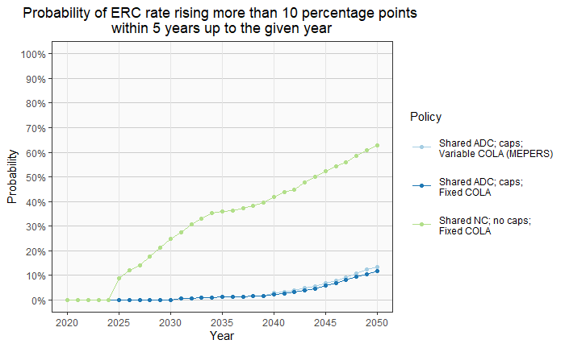

#### Risk of sharp EEC increase

This graph shows the probability that the EEC rate will rise by more than 5 percentage points within any 5-year period leading up to the current year. For example, in 2035 it shows the probability that the EEC rose by 5 percentage points or more in any prior 5-year period (2020-2024, 2021-2025, …, 2031-2035). This is designed to show whether the plan member was likely to face a sharp increase in contribution costs in a short period of time, during the period examined . Note that we use a 5 percentage point change for the EEC and a 10 percentage point change for the ERC, on the belief that individuals may consider a smaller sharp change to their take home pay to be quite significant.

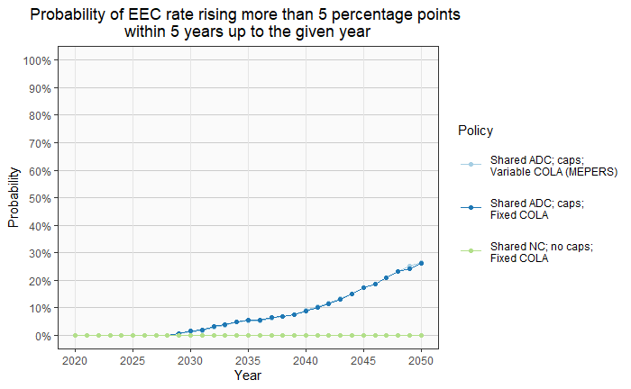

## 3.3 **Analysis of funded status**

### Risk of low funded ratio (cumulative)

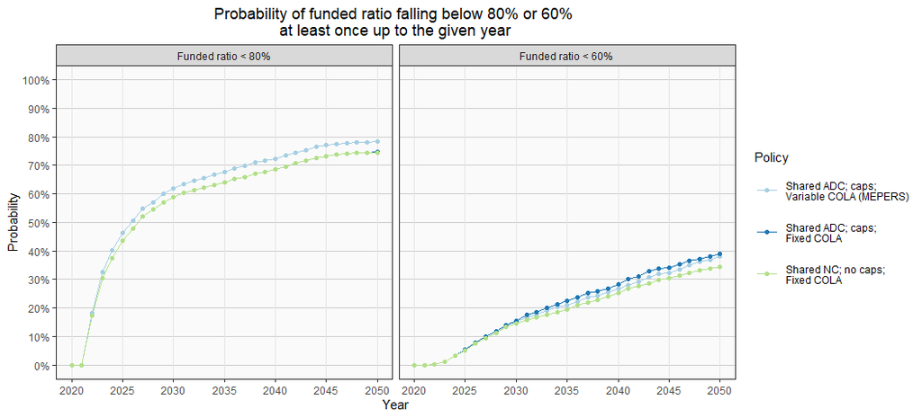

### Risk of low funded ratio (non-cumulative)

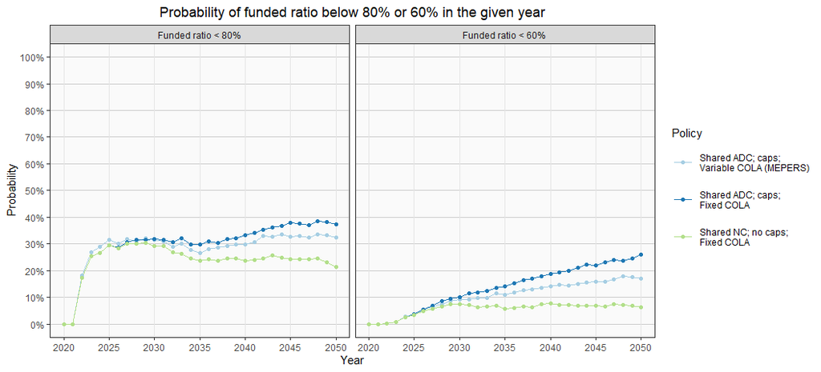

### Probability of full funding

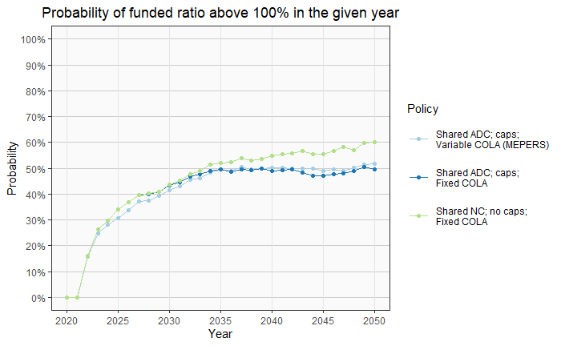

## 3.4 **Analysis of member benefit**

Cohort examined:

- Joined the plan at age 25 in 1986
- Start receiving benefit at age 60 in 2021
- live to age 90 (30 years in retirement)

### distribution of present value of benefit

Distribution of 30-year present value of benefit

For members who retire at age 60 with 35 years of service in 2021

| Policy | 90th | 75th | 50th | 25th | 10th |
| --- | --- | --- | --- | --- | --- |
| Shared ADC; caps; Variable COLA (MEPERS) | 1,769 | 1,769 | 1,697 | 1,570 | 1,482 |
| Shared ADC; caps; Fixed COLA | 1,657 | 1,657 | 1,657 | 1,657 | 1,657 |

Note: starting benefit is normalized to $100

### distribution of replacement rate at age 75

Distribution of replacement rate at age 75

For members who retire at age 60 with 35 years of service in 2021

| Policy | 90th | 75th | 50th | 25th | 10th |
| --- | --- | --- | --- | --- | --- |
| Shared ADC; caps; Variable COLA (MEPERS) | 0.67 | 0.67 | 0.64 | 0.55 | 0.51 |
| Shared ADC; caps; Fixed COLA | 0.62 | 0.62 | 0.62 | 0.62 | 0.62 |

Note: benefits at age 75 are adjusted for inflation; assumed inflation = 2.75% (MEPERS assumption)